# Visit With Us Procject

# Data Visualization (EDA)

```python
#apply str manipulation functions
def toc(x):
    if x == 'Self Enquiry':
        return 0
    else:
        return 1

df['Gender'] = df['Gender'].apply(lambda x: x.replace(' ','').capitalize())
df['Invited'] = df['TypeofContact'].apply(toc)

#Dropping two columns(TypeofContact,CustomerID)
df.drop(columns=['TypeofContact','CustomerID'], inplace=True)
```

# Univariate Analysis ,Bivariate Analysis and Roc Curves

```python
#convert dummy variables to counts to generate bar charts for univariate analysis
prodtaken = np.unique(df['ProdTaken'], return_counts=True)
passport = np.unique(df['Passport'], return_counts=True)
owncar = np.unique(df['OwnCar'], return_counts=True)
productpitched = np.unique(df['ProductPitched'], return_counts=True)
invited = np.unique(df['Invited'], return_counts=True)
occupation = np.unique(df['Occupation'], return_counts=True)
gender = np.unique(df['Gender'], return_counts=True)
maritalstatus = np.unique(df['MaritalStatus'], return_counts=True)
designation = np.unique(df['Designation'], return_counts=True)
```

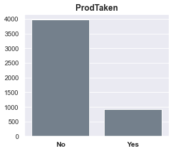

```python
#plot data spread
fig = plt.figure(figsize = [20,28]);
fig.subplots_adjust(hspace=0.6, wspace=0.2);

plt.subplot(5,4,1);
sns.barplot(x = prodtaken[0], y=prodtaken[1], color='slategrey');
plt.title('ProdTaken', fontsize=14, fontweight='bold');
plt.xticks([0,1],['No','Yes'], fontsize=12, fontweight='bold');
```

From above figure Whether the customer has purchased a package or not (0: No, 1: Yes) Most people are not purchasing anything as you see.

[output not shown]

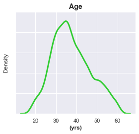

```python
# Age of customer are mostly
fig = plt.figure(figsize = [20,28]);
fig.subplots_adjust(hspace=0.6, wspace=0.2);

plt.subplot(5,4,2);
sns.distplot(df['Age'], hist=False, kde_kws=dict(linewidth=3), color='limegreen');
plt.title('Age', fontsize=14, fontweight='bold');
plt.xlabel('(yrs)', fontsize=12, fontweight='bold');
plt.yticks(np.arange(0,0.051,0.01),labels=['','','','','',''])
```

From above figure Age of customer are mostly between 25 to 40 and a very small number people which is less then 20 years old and more than 60 years old.

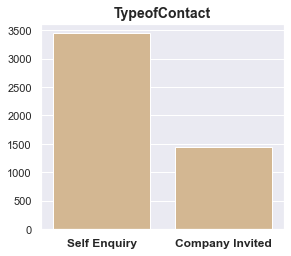

```python
# Types of contact
fig = plt.figure(figsize = [20,28]);
fig.subplots_adjust(hspace=0.6, wspace=0.2);

plt.subplot(5,4,3);
sns.barplot(x = invited[0], y=invited[1], color='burlywood');
plt.title('TypeofContact', fontsize=14, fontweight='bold');
plt.xticks(np.arange(0,2),['Self Enquiry', 'Company Invited'], fontsize=12, fontweight='bold');
```

From above figure How customer was contacted (Company Invited or Self Inquiry) Most of people are contracted as a self Enquiry and average number of people are company invited.

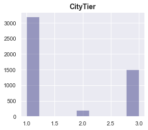

```python
# CityTier
fig = plt.figure(figsize = [20,28]);
fig.subplots_adjust(hspace=0.6, wspace=0.2);

plt.subplot(5,4,4);
sns.distplot(df['CityTier'], hist=True, kde=False, color='midnightblue');
plt.title('CityTier', fontsize=14, fontweight='bold');
plt.xlabel('', fontsize=12, fontweight='bold');
```

From above figure City tier depends on the development of a city, population, facilities, and living and most of are come from the population side.

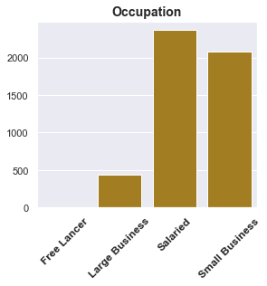

```python
# Occupation
fig = plt.figure(figsize = [20,28]);
fig.subplots_adjust(hspace=0.6, wspace=0.2);

plt.subplot(5,4,5);
sns.barplot(x = occupation[0], y=occupation[1], color='darkgoldenrod');
plt.title('Occupation', fontsize=14, fontweight='bold');
plt.xticks(np.arange(0,4),['Free Lancer', 'Large Business', 'Salaried', 'Small Business'], fontsize=12, fontweight='bold', rotation=45);
```

From above figure Most of Occupation of customer are Salaried based or have a small business. And a very low people have occupation of Large Business.

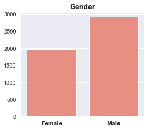

```python
# To identify either male goes most or female
fig = plt.figure(figsize = [20,28]);
fig.subplots_adjust(hspace=0.6, wspace=0.2);

plt.subplot(5,4,6);
sns.barplot(x = gender[0], y=gender[1], color='salmon');
plt.title('Gender', fontsize=14, fontweight='bold');
plt.xticks(np.arange(0,2),['Female', 'Male'], fontsize=12, fontweight='bold');
```

From above figure Gender of customer are Male those who going most as compare to Female.

[output not shown]

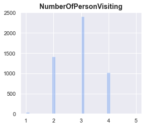

```python
# To check how many Number of Person Visiting with other customer
fig = plt.figure(figsize = [20,28]);
fig.subplots_adjust(hspace=0.6, wspace=0.2);

plt.subplot(5,4,7);
sns.distplot(df['NumberOfPersonVisiting'], hist=True, kde=False, color='cornflowerblue');
plt.title('NumberOfPersonVisiting', fontsize=14, fontweight='bold');
plt.xlabel('', fontsize=12, fontweight='bold');
plt.xticks(np.arange(1,6,1))
```

From above figure Total number of persons planning to take the trip with the customer are 2 to 4

[output not shown]

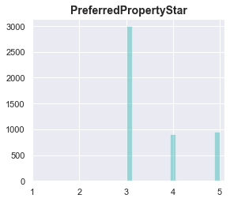

```python
# To check the Preferred Property Star rating by customer
fig = plt.figure(figsize = [20,28]);
fig.subplots_adjust(hspace=0.6, wspace=0.2);

plt.subplot(5,4,8);
sns.distplot(df['PreferredPropertyStar'], hist=True, kde=False, color='lightseagreen');
plt.title('PreferredPropertyStar', fontsize=14, fontweight='bold');
plt.xlabel('', fontsize=12, fontweight='bold');
plt.xticks(np.arange(1,6,1))
```

From above we identify that Preferred hotel property rating by customer are 3 to 5 people